# Sundar_Swati_MSDS458_Assignment_04_EDA

[figure not shown]

## Dataset Overview

The Chest X-ray dataset from Indiana University has two sets of files, one contains an X-ray image of patients, and the other includes radiology reports of that particular patient in XML format (https://academictorrents.com/details/5a3a439df24931f410fac269b87b050203d9467d). The report could be associated with more than one image. The XML fields are image_id, the caption of an image, indication of patient, findings, and impression. There are 7471 X-ray images and 3955 reports in the dataset. The impression is the target feature.

## Import packages

```python
#Ignore Warning
import warnings
warnings.filterwarnings("ignore")
# set up notebook to display multiple outputs in one cell
from IPython.core.interactiveshell import InteractiveShell
InteractiveShell.ast_node_interactivity = "all"
```

```python
import datetime
from packaging import version
import tarfile
from collections import Counter
import numpy as np
import pandas as pd
import time
import string
import os # Operation System
from tqdm import tqdm
import xml.etree.ElementTree as et
import re

from timeit import default_timer as timer
import time
from datetime import timedelta

import matplotlib.pyplot as plt
import matplotlib as mpl
import seaborn as sns

from wordcloud import WordCloud, STOPWORDS# to visualize wordcloud
import cv2
from google.colab.patches import cv2_imshow

from sklearn.model_selection import train_test_split
from sklearn.utils import resample


import tensorflow as tf
from tensorflow import keras
import tensorflow_datasets as tfds
from tensorflow.keras.layers import TextVectorization
```

```python
%matplotlib inline
np.set_printoptions(precision=3, suppress=True)
```

## Verify TensorFlow version and Keras version

```python
print("This notebook requires TensorFlow 2.0 or above")
print("TensorFlow version: ", tf.__version__)
assert version.parse(tf.__version__).release[0] >=2
print("Keras version: ", keras.__version__)
```

```
This notebook requires TensorFlow 2.0 or above
TensorFlow version:  2.8.2
Keras version:  2.8.0
```

## Mount Google Drive to Colab environment

```python
from google.colab import drive
drive.mount('/content/gdrive')
```

```python
%cd /content/gdrive/My Drive/MSDS/458-ANN/Assignment 4/
!pwd
#!ls
print('Working Directory')
print(os.getcwd())
work_dir = "/content/gdrive/My Drive/MSDS/458-ANN/Assignment 4/"
```

```
/content/gdrive/My Drive/MSDS/458-ANN/Assignment 4
/content/gdrive/My Drive/MSDS/458-ANN/Assignment 4
Working Directory
/content/gdrive/My Drive/MSDS/458-ANN/Assignment 4
```

## Utility Functions

```python
# Remove Text expansion of words ('ll to will)
def decontracted(phrase):
  # specific
  phrase = re.sub(r"won\'t", "will not", phrase)
  phrase = re.sub(r"can\'t", "can not", phrase)

  # general
  phrase = re.sub(r"n\'t", " not", phrase)
  phrase = re.sub(r"\'re", " are", phrase)
  phrase = re.sub(r"\'s", " is", phrase)
  phrase = re.sub(r"\'d", " would", phrase)
  phrase = re.sub(r"\'ll", " will", phrase)
  phrase = re.sub(r"\'t", " not", phrase)
  phrase = re.sub(r"\'ve", " have", phrase)
  phrase = re.sub(r"\'m", " am", phrase)
  return phrase


def get_info(data):
  regex = r"\d."
  k = re.sub(regex,"", data) #removing all values like "1." and "2." etc

  regex = r"X+"
  k = re.sub(regex,"",k) #removing words like XXXX

  regex = r" \."
  k = re.sub(regex,"",k) #removing singular fullstop ie " ."

  regex = r"[^.a-zA-Z]"
  k = re.sub(regex," ",k) #removing all special characters except for full stop

  regex = r"\."
  k = re.sub(regex," .",k) #adding space before fullstop
  k = decontracted(k) #perform decontraction
  k = k.strip().lower() #strips the begining and end of the string of spaces and converts all into lowercase
  k = " ".join(k.split()) #removes unwanted spaces
  if k=="": #if the resulting sentence is an empty string return null value
    k = np.nan
  return k
```

## Data Extraction

```python
# Uncomment and run the zip extraction code for first time execution only.
#xmlReport = tarfile.open(work_dir + 'data/reports/NLMCXR_reports.tgz')
extractedFolder = work_dir +'data/reports/extracted/'
# xmlReport.extractall(extractedFolder)
```

```python
reportCnt = len(os.listdir(extractedFolder + 'ecgen-radiology'))
print('The number of reports in the data are: %i'%(reportCnt))
```

```
The number of reports in the data are: 3955
```

```python
#visualize a report xml tree structure.
with open(extractedFolder + 'ecgen-radiology/1.xml', 'r') as f:
    print(f.read())
```

```
<?xml version="1.0" encoding="utf-8"?>
<eCitation>
   <meta type="rr"/>
   <uId id="CXR1"/>
   <pmcId id="1"/>
   <docSource>CXR</docSource>
   <IUXRId id="1"/>
   <licenseType>open-access</licenseType>
   <licenseURL>http://creativecommons.org/licenses/by-nc-nd/4.0/</licenseURL>
   <ccLicense>byncnd</ccLicense>
   <articleURL/>
   <articleDate>2013-08-01</articleDate>
   <articleType>XR</articleType>
   <publisher>Indiana University</publisher>
   <title>Indiana University Chest X-ray Collection</title>
   <note>The data are drawn from multiple hospital systems.</note>
   <specialty>pulmonary diseases</specialty>
   <subset>CXR</subset>
   <MedlineCitation Owner="Indiana University" Status="supplied by publisher">

      <Article PubModel="Electronic">

         <Journal>

            <JournalIssue>

               <PubDate>

                  <Year>2013</Year>

                  <Month>08</Month>

                  <Day>01</Day>

               </PubDate>

            </JournalIssue>

         </Journal>

```

[output cut: 156 more lines]

```

               <SemanticContext60>f3p0k277</SemanticContext60>


            </globalImageFeatures>


         </region>


      </panel>


   </parentImage>
</eCitation>
```

```python
# Uncomment and run the zip extraction code for first time execution only.
# images = tarfile.open(work_dir + 'data/images/NLMCXR_png.tgz')
extractedImageFolder = work_dir +'data/images/extracted/'
# images.extractall(extractedImageFolder)
```

```python
imgCnt = len(os.listdir(extractedImageFolder))
print('The number of chest xray images in the data are: %i'%(imgCnt))
```

```
The number of chest xray images in the data are: 7471
```

```
1)
```

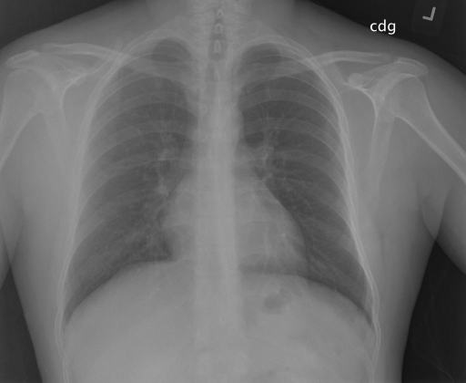

```
		 CXR2609_IM-1099-3001.png
2)
```

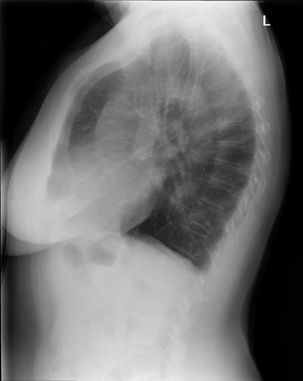

```
		 CXR2794_IM-1226-1002.png
3)
```

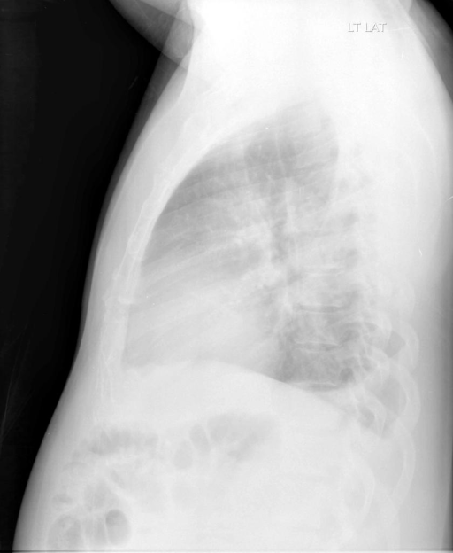

```
		 CXR3148_IM-1480-2001.png
```

```python
#showing random 3 images
np.random.seed(420)
for i in range(3):
  k = np.random.choice(range(imgCnt))
  image_file = os.listdir(extractedImageFolder)[k]
  image = cv2.imread(os.path.join(extractedImageFolder,image_file)) #getting an image file
  print("%i)\n"%(i+1))
  cv2_imshow(image)
  print("\t\t",image_file)
```

```python
Image_count = []
for file in tqdm(os.listdir(extractedFolder + 'ecgen-radiology/')):
  if file.endswith(".xml"):
    k = extractedFolder + "ecgen-radiology/"
    path = k + file
    reportTree = et.parse(path)# parse xml tree
    imgtrees = reportTree.findall("parentImage")
    Image_count.append(len(imgtrees))
```

```python
print("The max no. of images associated with a report: %i"%(max(Image_count)))
print("The min no. of images associated with a report: %i"%(min(Image_count)))
```

```
The max no. of images associated with a report: 5
The min no. of images associated with a report: 0
```

```python
# check the distribution of number of images associated with reports.
values = pd.Series(Image_count).value_counts()
```

[output not shown]

```
2    3208
1     446
3     181
0     104
4      15
5       1
dtype: int64
```

```
 [Text(-0.615071945989818, -0.911968476021128, ''),
 [Text(-0.47528286735576836, -0.7047029132890533, '81.1%'),
```

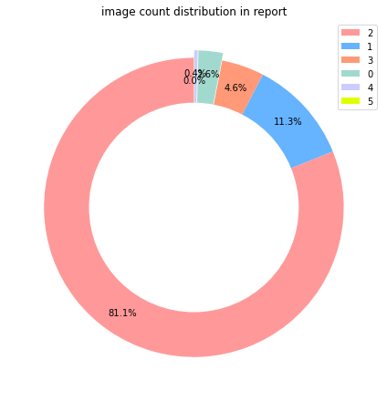

```python
# Visualize the distribution in pie chart of number of images associated with reports.
values = pd.Series(Image_count).value_counts()

print(values)
#define color palette to use
colors = ['#ff9999','#66b3ff', '#ff9977','#A2D9CE', '#CCCCFF','#DFFF00']


#explosion
explode = (0,0,0,0.05,0.05,0)
#create pie chart to see the distribution of target variable of interest
plt.pie(values, colors = colors, autopct='%1.1f%%', startangle=90, pctdistance=0.85, explode = explode)
#draw circle
centre_circle = plt.Circle((0,0),0.70,fc='white')
plt.legend(values.index, loc="best")
fig = plt.gcf()
fig.gca().add_artist(centre_circle)
fig.set_size_inches(6,10)
# Equal aspect ratio ensures that pie is drawn as a circle
plt.title("image count distribution in report")
plt.tight_layout()
plt.show()
```

We can see that the maximum number of images associated with a report can be 5 while the minimum is 0. Next step is to extract all the information part i.e. comparison, indication, findings and impression part of the report and the corresponding 2 images (we will take 2 images as input as 2 images are highest frequecy of being associated with a report) of the concerned report to a dataframe with xml report file name. For images more than 2, we will create new datapoint with new images and same info.

## Data Preprocessing

```python
# Declare the columns for dataframe
columns = ["image_id1", "image_id2", "caption", "comparison", "indication", "findings", "impression","xml_File","height_img1","width_img1","height_img2","width_img2"]
```

```python
# Create a blank dataframe with column names
df_reports = pd.DataFrame(columns = columns)
```

```python
# display the dataframe
df_reports.head()
```

|  | image_id1 | image_id2 | caption | comparison | indication | findings | impression | xml_File | height_img1 | width_img1 | height_img2 | width_img2 |
| --- | --- | --- | --- | --- | --- | --- | --- | --- | --- | --- | --- | --- |

```python
img1 = [] #there are 2 images associated with a report
img2 = []
h1 = [] # height & width of image 1
w1 = []
h2 = [] # height & width of image 2
w2= []
#stores info
captions = [] # Caption in the report
comparisons = [] # comparision node in the report
indications = [] # Indication node in the report
findings = [] # finding node in the report
impressions = [] # impression node in the report
report_name = [] #stores xml file name
for file in tqdm(os.listdir(extractedFolder + 'ecgen-radiology/')):
    if file.endswith(".xml"):
        k = extractedFolder + "ecgen-radiology/"
        path = k + file
        mytree = et.parse(path)# parsing xml report
        comparision = mytree.find(".//AbstractText[@Label='COMPARISON']").text # extracting comaparison text
        indication = mytree.find(".//AbstractText[@Label='INDICATION']").text #extracting indication text
        finding = mytree.find(".//AbstractText[@Label='FINDINGS']").text # extracting findings text
        impression = mytree.find(".//AbstractText[@Label='IMPRESSION']").text  # extracting impression text

        mytree = et.parse(path)
        imgtrees = mytree.findall("parentImage")
        if len(imgtrees)==2:
          image_id1 = imgtrees[0].attrib['id']+".png"
          image_id2 = imgtrees[1].attrib['id']+".png"
          caption = '' if imgtrees[0].find('caption').text is None else imgtrees[0].find('caption').text
          # print(image_id1)
          # print(image_id2)
          # print(caption)
          filename1 = work_dir + 'data/images/extracted/' + image_id1
          image1 = cv2.imread(filename1) # reading image1

          filename2 = work_dir + 'data/images/extracted/' + image_id2
          image2 = cv2.imread(filename2) # reading image2

          height1, width1, channels1 = image1.shape
          height2, width2, channels2 = image2.shape

          img2.append(image_id2)
          img1.append(image_id1)
          h1.append(height1)
          w1.append(width1)
          h2.append(height2)
          w2.append(width2)
          captions.append(caption)
          comparisons.append(comparision)
          indications.append(indication)
          findings.append(finding)
          impressions.append(impression)
          report_name.append(file) #xml file name

        elif len(imgtrees)<2:
          try: #if the exception is raised means no image file name was found
            image_id1 = imgtrees[0].attrib['id']+".png"
            image_id2 =  np.nan
            caption = '' if imgtrees[0].find('caption').text is None else imgtrees[0].find('caption').text
            filename1 = work_dir + 'data/images/extracted/' + image_id1
            image1 = cv2.imread(filename1) # reading image1

            height1, width1, channels1 = image1.shape
            height2, width2 = np.nan, np.nan

          except:
            image_id1 = np.nan
            image_id2 =  np.nan
            height1, width1 = np.nan, np.nan
            height2, width2 = np.nan, np.nan

          img1.append(image_id1)
          img2.append(image_id2)
          h1.append(height1)
          w1.append(width1)
          h2.append(height2)
          w2.append(width2)
          captions.append(caption)
          comparisons.append(comparision)
          indications.append(indication)
          findings.append(finding)
          impressions.append(impression)
          report_name.append(file) #xml file name
        else: #if there are more than 2 images concerned with report
          for i in range(len(imgtrees)-1):
            image_id1 = imgtrees[i].attrib['id']+".png"
            image_id2 = imgtrees[i+1].attrib['id']+".png"
            caption = '' if imgtrees[i].find('caption').text is None else imgtrees[i].find('caption').text
            filename1 = work_dir + 'data/images/extracted/' + image_id1
            image1 = cv2.imread(filename1) # reading image1
            filename2 = work_dir + 'data/images/extracted/' + image_id2
            image2 = cv2.imread(filename2) # reading image2

            height1, width1, channels1 = image1.shape
            height2, width2, channels2 = image2.shape

            img1.append(image_id1)
            img2.append(image_id2)
            h1.append(height1)
            w1.append(width1)
            h2.append(height2)
            w2.append(width2)
            captions.append(caption)
            comparisons.append(comparision)
            indications.append(indication)
            findings.append(finding)
            impressions.append(impression)
            report_name.append(file) #xml file name

# print(img1)
# print(h1)
# print(w2)
dfreport = pd.DataFrame({"image_1":img1,"image_2":img2,"caption":captions,"comparison":comparisons,"indication":indications,
                   "findings":findings,"impression":impressions,"xml file name":report_name,"height1":h1,"width1":w1,"height2":h2,"width2":w2})
```

```python
dfreport.shape
```

```
(4169, 12)
```

```python
dfreport.to_csv('dfreport.csv', index=False)
```

```python
df = pd.read_csv(work_dir + 'dfreport.csv', index_col=False)
df.shape
```

```
(4169, 12)
```

```python
df["caption"]
```

```
0                  Chest radiographs, 2 XXXX and lateral
1       Radiographs of the chest, 2 views, PA and late...
2                               Xray Chest PA and Lateral
3                  Chest radiographs, 2 XXXX and lateral
4       PA and Lateral Chest Radiograph XXXX, XXXX at ...
                              ...
4164    PA and Lateral Chest Radiograph XXXX, XXXX at ...
4165                            Xray Chest PA and Lateral
4166                                 PA and Lateral Chest
4167    Radiographs of the chest, 2 views, dated XXXX,...
4168                             CHEST 2V FRONTAL/LATERAL
Name: caption, Length: 4169, dtype: object
```

```python
#perform decontrction and text cleaning
captions = []
for caption in df["caption"].apply(str):
  captions.append(get_info(caption))
df['caption'] = captions
```

```python
#perform decontrction and text cleaning
findings =[]
for finding in df["findings"].apply(str):
  findings.append(get_info(finding))
df['findings'] = findings
```

```python
#perform decontrction and text cleaning
comparision = []
for comparison in df["comparison"].apply(str):
  comparision.append(get_info(comparison))
df['comparison'] = comparision
```

```python
#perform decontrction and text cleaning
indications = []
for indication in df["indication"].apply(str):
  indications.append(get_info(indication))
df['indication'] = indications
```

```python
#perform decontrction and text cleaning
impressions = []
for impression in df["impression"].apply(str):
  impressions.append(get_info(impression))
df['impression'] = impressions
```

```python
df.info()
```

```
<class 'pandas.core.frame.DataFrame'>
RangeIndex: 4169 entries, 0 to 4168
Data columns (total 12 columns):
 #   Column         Non-Null Count  Dtype
---  ------         --------------  -----
 0   image_1        4065 non-null   object
 1   image_2        3619 non-null   object
 2   caption        4168 non-null   object
 3   comparison     3428 non-null   object
 4   indication     3999 non-null   object
 5   findings       4169 non-null   object
 6   impression     4169 non-null   object
 7   xml file name  4169 non-null   object
 8   height1        4065 non-null   float64
 9   width1         4065 non-null   float64
 10  height2        3619 non-null   float64
 11  width2         3619 non-null   float64
dtypes: float64(4), object(8)
memory usage: 391.0+ KB
```

```python
df.head()
df.tail()

# Summary Statistics of Dataset
df.describe()
```

|  | image_1 | image_2 | caption | comparison | indication | findings | impression | xml file name | height1 | width1 | height2 | width2 |
| --- | --- | --- | --- | --- | --- | --- | --- | --- | --- | --- | --- | --- |
| 0 | CXR3402_IM-1646-1001.png | CXR3402_IM-1646-2001.png | chest radiographs and lateral | NaN | year old female with chest pain | the heart size and mediastinal contours appear... | no acute cardiopulmonary findings . | 3402.xml | 624.0 | 512.0 | 624.0 | 512.0 |
| 1 | CXR3403_IM-1647-1001.png | CXR3403_IM-1647-2001.png | radiographs of the chest views pa and lateral ... | none . | year old female . left chest pain . right rib ... | the cardiomediastinal silhouette is normal in ... | negative for acute abnormality . | 3403.xml | 512.0 | 512.0 | 512.0 | 512.0 |
| 2 | CXR3404_IM-1647-1001.png | CXR3404_IM-1647-2001.png | ray chest pa and lateral | NaN | chronic left mastectomy | the heart is normal in size . the mediastinum ... | no acute disease . | 3404.xml | 512.0 | 512.0 | 532.0 | 512.0 |
| 3 | CXR3406_IM-1647-1001.png | CXR3406_IM-1647-2001.png | chest radiographs and lateral | NaN | year old female with pain left upper back | the heart size and mediastinal contours appear... | no acute cardiopulmonary findings . | 3406.xml | 420.0 | 512.0 | 624.0 | 512.0 |
| 4 | CXR3405_IM-1647-1001.png | CXR3405_IM-1647-2001.png | pa and lateral chest radiograph at a .m . | ct chest | year old female with chest pain | the heart is normal size . the mediastinum is ... | no acute cardiopulmonary abnormality . | 3405.xml | 420.0 | 512.0 | 624.0 | 512.0 |

|  | image_1 | image_2 | caption | comparison | indication | findings | impression | xml file name | height1 | width1 | height2 | width2 |
| --- | --- | --- | --- | --- | --- | --- | --- | --- | --- | --- | --- | --- |
| 4164 | CXR811_IM-2343-1001.png | CXR811_IM-2343-2001.png | pa and lateral chest radiograph at a .m . | chest radiograph | year old female with chest pain | the heart is normal size . the mediastinum is ... | no acute cardiopulmonary abnormality . | 811.xml | 420.0 | 512.0 | 624.0 | 512.0 |
| 4165 | CXR793_IM-2330-1001.png | CXR793_IM-2330-2001.png | ray chest pa and lateral | nan | dyspnea shortness of breath lightheadedness . | the examination consists of frontal and latera... | no evidence of acute cardiopulmonary process . | 793.xml | 512.0 | 512.0 | 574.0 | 512.0 |
| 4166 | CXR780_IM-2323-1001.png | CXR780_IM-2323-2001.png | pa and lateral chest | none available . | preop bilateral leg gangrene . | heart size is upper limits of normal . mediast... | clear lungs . no acute cardiopulmonary findings . | 780.xml | 512.0 | 512.0 | 519.0 | 512.0 |
| 4167 | CXR796_IM-2332-1001.png | CXR796_IM-2332-2001.png | radiographs of the chest views dated at hours . | none . | year old female . chest pain . | the cardiomediastinal silhouette is normal in ... | negative for acute abnormality . | 796.xml | 420.0 | 512.0 | 624.0 | 512.0 |
| 4168 | CXR790_IM-2329-1001.png | CXR790_IM-2329-1002.png | chest frontal lateral | none | loss | both lungs are clear and expanded . heart and ... | no active disease . | 790.xml | 509.0 | 512.0 | 509.0 | 512.0 |

|  | height1 | width1 | height2 | width2 |
| --- | --- | --- | --- | --- |
| count | 4065.000000 | 4065.0 | 3619.00000 | 3619.0 |
| mean | 504.751046 | 512.0 | 564.64189 | 512.0 |
| std | 74.680995 | 0.0 | 75.53680 | 0.0 |
| min | 362.000000 | 512.0 | 394.00000 | 512.0 |
| 25% | 420.000000 | 512.0 | 512.00000 | 512.0 |
| 50% | 512.000000 | 512.0 | 613.00000 | 512.0 |
| 75% | 523.000000 | 512.0 | 624.00000 | 512.0 |
| max | 756.000000 | 512.0 | 873.00000 | 512.0 |

### Missing values and outliers

```python
# Checking for Missing values in train dataset
print('Missing value in extracted report data: ',df.isnull().sum())
```

```
Missing value in extracted report data:  image_1          104
image_2          550
caption            1
comparison       741
indication       170
findings           0
impression         0
xml file name      0
height1          104
width1           104
height2          550
width2           550
dtype: int64
```

```python
#Drop the null values for impression, image1, height1 & width1
df.drop(df[(df['impression'].isnull())|(df['image_1'].isnull())|(df['height1'].isnull())|(df['width1'].isnull())].index,inplace=True)
df = df.reset_index(drop=True).copy()
print("%i datapoints were removed.\nFinal no. of datapoints: %i"%(4169-df.shape[0],df.shape[0]))
```

```
104 datapoints were removed.
Final no. of datapoints: 4065
```

we can use the same image file in image 1 for missing values in image 2

```python
#replace the null values for image2, height2 & width2 with image1, height1 & width1.
%%time
df.loc[df.image_2.isnull(),'image_2'] = df[df.image_2.isnull()]['image_1'].values
df.loc[df.height2.isnull(),'height2'] = df[df.height2.isnull()]['height1'].values
df.loc[df.width2.isnull(),'width2'] = df[df.width2.isnull()]['width1'].values
```

```
CPU times: user 7.02 ms, sys: 173 µs, total: 7.19 ms
Wall time: 6.48 ms
```

```python
#verify the missing value to ensure no null values for input (image1, image2) & target (impression) feature exists
df.isnull().sum()
```

```
image_1            0
image_2            0
caption            1
comparison       717
indication       169
findings           0
impression         0
xml file name      0
height1            0
width1             0
height2            0
width2             0
dtype: int64
```

```python
#save the cleaned dataframe
df.to_csv('df_report_final.csv', index=False)
```

```python
#read the cleaned dataframe
df = pd.read_csv(work_dir + 'df_report_final.csv', index_col=False)
df.shape
```

```
(4065, 12)
```

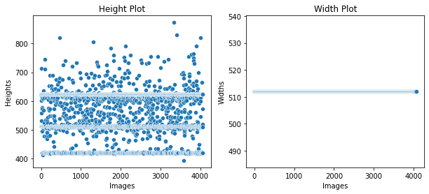

```python
#visualize the height & width distribution of all images extracted
plt.figure(figsize=(10,4))
plt.subplot(121)
plt.title('Height Plot')
plt.ylabel('Heights')
plt.xlabel('Images')
sns.scatterplot(range(len(df.height1.values)), df.height2.values)
plt.subplot(122)
plt.title('Width Plot')
plt.ylabel('Widths')
plt.xlabel('Images')
sns.scatterplot(range(len(df.width1.values)), df.width2.values)
```

```python
print("\n\nValue Counts of image 1 heights:\n")
print(df.height1.value_counts())
print("Value Counts of image 2 heights:\n")
print(df.height2.value_counts())
```

```
Value Counts of image 1 heights:

420.0    1135
512.0     937
624.0     676
511.0     235
618.0      90
         ...
399.0       1
565.0       1
620.0       1
567.0       1
404.0       1
Name: height1, Length: 198, dtype: int64
Value Counts of image 2 heights:

624.0    1458
512.0     724
420.0     461
511.0     218
618.0      93
         ...
450.0       1
687.0       1
466.0       1
634.0       1
666.0       1
Name: height2, Length: 263, dtype: int64
```

```python
print("\n\nValue Counts of image 1 widths:\n")
print(df.width1.value_counts())
print("Value Counts of image 2 widths:\n")
print(df.width2.value_counts())
```

```
Value Counts of image 1 widths:

512.0    4065
Name: width1, dtype: int64
Value Counts of image 2 widths:

512.0    4065
Name: width2, dtype: int64
```

### Exploratory Data Analysis

```python
def show_image_captions(df = df,image_folder = extractedImageFolder,sample = 5):
  k = df.sample(sample)
  i=1
  for index,row in k.iterrows():
    image_1 = cv2.imread(os.path.join(image_folder,row.get('image_1')))
    image_2 = cv2.imread(os.path.join(image_folder,row.get('image_2')))

    plt.figure(figsize = (12,8)) #setting the figure size
    plt.subplot(121) #first x-ray
    plt.imshow(image_1,aspect='auto')

    plt.subplot(122) #2nd x-ray
    plt.imshow(image_2, aspect = 'auto')
    print("%i)\n"%(i))
    i+=1
    plt.show() #printing the image
    print("\n","Caption: ",row.get('caption'))
    print("\n","Comparison: ",row.get('comparison'))
    print("\n","Indication: ",row.get('indication'))
    print("\n","Findings: ",row.get('findings'))
    print("\n","Impression: ",row.get('impression'),"\n\n","*"*150,"\n\n")
```

```
1)
```

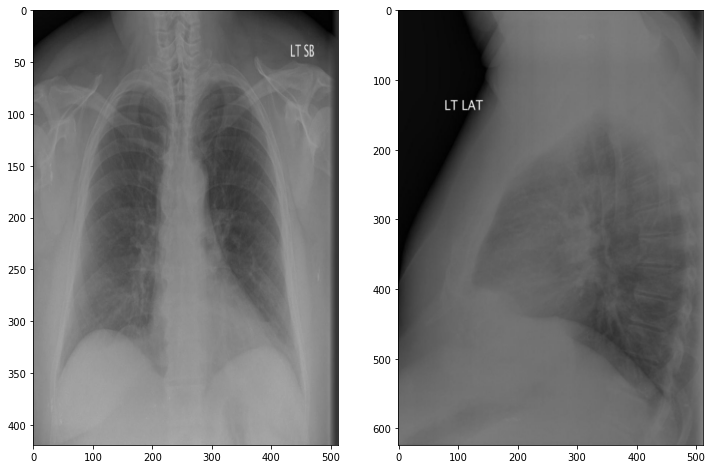

[output not shown]

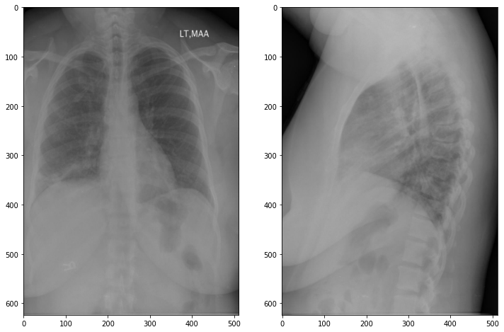

```
 Caption:  CHEST 2V FRONTAL/LATERAL

 Comparison:  None

 Indication:  Shortness of breath

 Findings:  The heart is normal in size. The mediastinum is unremarkable. There is patchy infiltrate within normal right lower lobe. Mild XXXX opacities in the retrocardiac region. No large effusions or pneumothorax.

 Impression:  Patchy right lower lobe infiltrate as well as probable left basilar infiltrate versus atelectasis.



3)
```

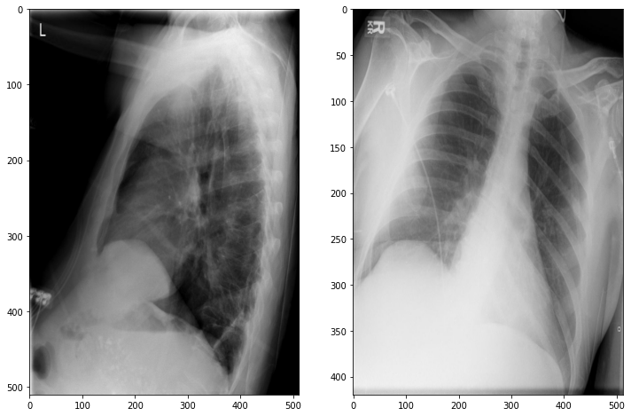

```
 Caption:  2 VIEW CHEST: XXXX, XXXX at XXXX hours.

 Comparison:  None

 Indication:  EtOH, diabetes, altered mental status

 Findings:  nan

 Impression:  Heart size is within normal limits. No edema. Bandlike scarring in the right base. No pleural effusion, lobar consolidation or pneumothorax. Multiple coarse calcifications in the epigastrium are seen on the lateral radiograph, not well localized on the frontal image. Could represent pa…



4)
```

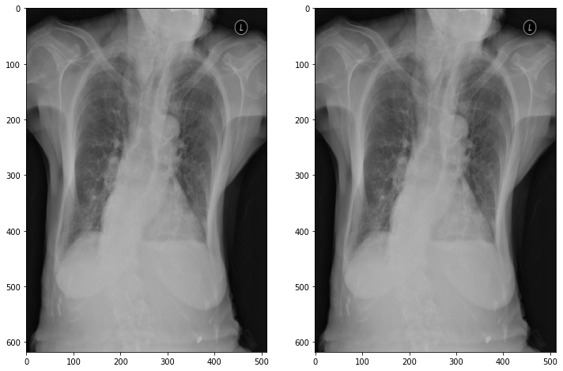

```
 Caption:  CHEST (PA AND LATERAL)

 Comparison:  XXXX, XXXX.

 Indication:  XXXX-year-old female status post XXXX.

 Findings:  Stable appearance of the cardiomediastinal silhouette. The aorta is calcified and tortuous. There is dextroscoliosis of the thoracolumbar spine. Multiple thoracic XXXX deformities appear unchanged. There is no displaced rib fracture identified. There is no pneumothorax or large pleural e…

 Impression:  1. No acute posttraumatic finding. 2. Mild right basilar airspace consolidation may represent atelectasis versus infiltrate. 3. Changes of chronic lung disease.



5)
```

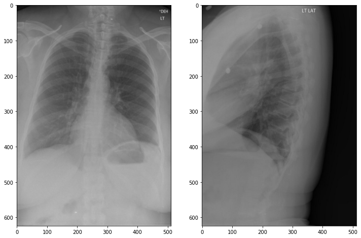

```
 Caption:  Chest radiographs, 2 XXXX and lateral

 Comparison:  XXXX, XXXX.

 Indication:  XXXX-year-old woman, short of breath.

 Findings:  Heart size within normal limits. Negative for focal pulmonary consolidation, pleural effusion, or pneumothorax. Mild degenerative changes thoracic spine.

 Impression:  No acute abnormality.
```

```python
show_image_captions()
```

### Wordcloud

```python
def show_wordcloud(data, title = None):
    stopwords = set(STOPWORDS)
    wordcloud = WordCloud(stopwords=stopwords,
                          background_color = 'white',
                          max_words=800,
                          max_font_size=60,
                          scale=3,
                          collocations=False,
                          random_state=1 ).generate(' '.join(data.astype(str)))

    fig = plt.figure(1, figsize=(12, 15))
    plt.axis('off')
    if title:
        fig.suptitle(title, fontsize=20)
        fig.subplots_adjust(top=2.3)

    plt.imshow(wordcloud)
    plt.show()
```

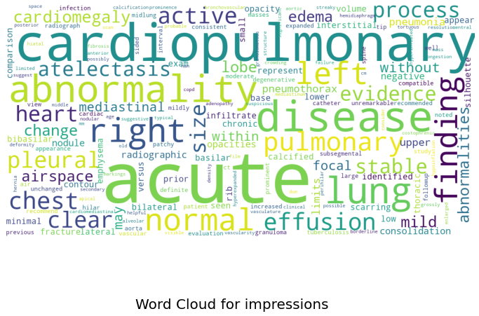

```python
show_wordcloud(df['impression'], "Word Cloud for impressions")
```

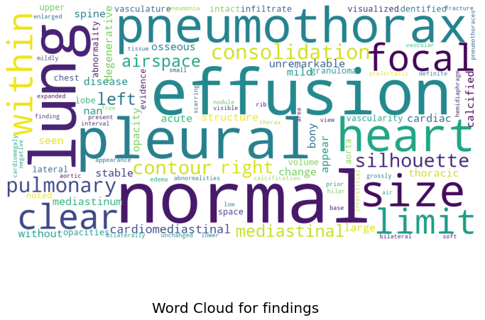

```python
show_wordcloud(df['findings'], "Word Cloud for findings")
```

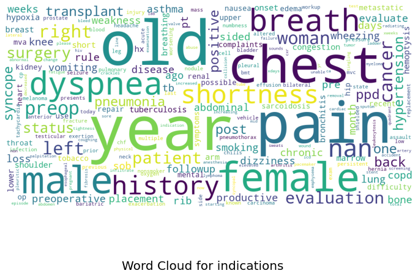

```python
show_wordcloud(df['indication'], "Word Cloud for indications")
```

## Train & Test Split

```python
#map the path of image directory
image_folder = work_dir + 'data/images/extracted/'
```

```python
# keep only required column
col = ['image_1','image_2','impression','xml file name']
df = df[col].copy()

df['image_1'] = df['image_1'].apply(lambda row: os.path.join(image_folder,row))
df['image_2'] = df['image_2'].apply(lambda row: os.path.join(image_folder,row))

df['impression_final'] = '<CLS> ' + df.impression + ' <END>' # Add start and end tokens for each text
df['impression_ip'] = '<CLS> ' + df.impression
df['impression_op'] = df.impression + ' <END>'
print(df.shape)
df.head(2)
```

```
(4065, 7)
```

|  | image_1 | image_2 | impression | xml file name | impression_final | impression_ip | impression_op |
| --- | --- | --- | --- | --- | --- | --- | --- |
| 0 | /content/gdrive/My Drive/MSDS/458-ANN/Assignme... | /content/gdrive/My Drive/MSDS/458-ANN/Assignme... | no acute cardiopulmonary findings . | 3402.xml | <CLS> no acute cardiopulmonary findings . <END> | <CLS> no acute cardiopulmonary findings . | no acute cardiopulmonary findings . <END> |
| 1 | /content/gdrive/My Drive/MSDS/458-ANN/Assignme... | /content/gdrive/My Drive/MSDS/458-ANN/Assignme... | negative for acute abnormality . | 3403.xml | <CLS> negative for acute abnormality . <END> | <CLS> negative for acute abnormality . | negative for acute abnormality . <END> |

```python
#check the target feature distribution before split to ensure equal population is sampled in train, test and validation split.
df['impression'].value_counts()
```

```
no acute cardiopulmonary abnormality .                                                                                                                                                                                                                                                                      …
no acute cardiopulmonary findings .                                                                                                                                                                                                                                                                         …
no acute cardiopulmonary disease .                                                                                                                                                                                                                                                                          …
no acute cardiopulmonary abnormalities .                                                                                                                                                                                                                                                                    …
no active disease .                                                                                                                                                                                                                                                                                         …
                                                                                                                                                                                                                                                                                                            …
patchy opacities in right upper lobe concerning for pneumonia given history . right paratracheal density possibly reactive lymphadenopathy . followup evaluation to resolution is recommended .                                                                                                             …
negative for acute abnormality . discrete projectile not seen .                                                                                                                                                                                                                                             …
negative acute bone abnormality . indeterminate cm opacity seen only on lateral view is of unknown clinical significance and may be located in or on the patient . clinical correlation with possible followup chest x recommended if clinically appropriate . dr . was notified of the indeterminate rounde…
mild cardiomegaly . basilar atelectasis .                                                                                                                                                                                                                                                                   …
clear lungs . no acute cardiopulmonary findings .                                                                                                                                                                                                                                                           …
Name: impression, Length: 1726, dtype: int64
```

```python
# drop duplicates for report
df.drop_duplicates(subset = ['xml file name'], inplace = True)
```

```python
k = df['impression'].value_counts()
df = df.merge(k,
         left_on = 'impression',
         right_index=True) #join left impression value with right index

df.columns
```

```
Index(['impression', 'image_1', 'image_2', 'impression_x', 'xml file name',
       'impression_final', 'impression_ip', 'impression_op', 'impression_y'],
      dtype='object')
```

```python
df.columns = ['impression', 'image_1', 'image_2', 'impression_x', 'xml file name','impression_final',
       'impression_ip', 'impression_op', 'impression_counts'] #changin column names
del df['impression_x'] #deleting impression_x column
df.head()
```

|  | impression | image_1 | image_2 | xml file name | impression_final | impression_ip | impression_op | impression_counts |
| --- | --- | --- | --- | --- | --- | --- | --- | --- |
| 0 | no acute cardiopulmonary findings . | /content/gdrive/My Drive/MSDS/458-ANN/Assignme... | /content/gdrive/My Drive/MSDS/458-ANN/Assignme... | 3402.xml | <CLS> no acute cardiopulmonary findings . <END> | <CLS> no acute cardiopulmonary findings . | no acute cardiopulmonary findings . <END> | 162 |
| 3 | no acute cardiopulmonary findings . | /content/gdrive/My Drive/MSDS/458-ANN/Assignme... | /content/gdrive/My Drive/MSDS/458-ANN/Assignme... | 3406.xml | <CLS> no acute cardiopulmonary findings . <END> | <CLS> no acute cardiopulmonary findings . | no acute cardiopulmonary findings . <END> | 162 |
| 18 | no acute cardiopulmonary findings . | /content/gdrive/My Drive/MSDS/458-ANN/Assignme... | /content/gdrive/My Drive/MSDS/458-ANN/Assignme... | 3420.xml | <CLS> no acute cardiopulmonary findings . <END> | <CLS> no acute cardiopulmonary findings . | no acute cardiopulmonary findings . <END> | 162 |
| 51 | no acute cardiopulmonary findings . | /content/gdrive/My Drive/MSDS/458-ANN/Assignme... | /content/gdrive/My Drive/MSDS/458-ANN/Assignme... | 345.xml | <CLS> no acute cardiopulmonary findings . <END> | <CLS> no acute cardiopulmonary findings . | no acute cardiopulmonary findings . <END> | 162 |
| 99 | no acute cardiopulmonary findings . | /content/gdrive/My Drive/MSDS/458-ANN/Assignme... | /content/gdrive/My Drive/MSDS/458-ANN/Assignme... | 3647.xml | <CLS> no acute cardiopulmonary findings . <END> | <CLS> no acute cardiopulmonary findings . | no acute cardiopulmonary findings . <END> | 162 |

```python
# spliting the dataset with stratified sampling.
other1 = df[df['impression_counts']>5] #selecting those datapoints which have impression valuecounts >5
other2 = df[df['impression_counts']<=5] #selecting those datapoints which have impression valuecounts <=5
train,test = train_test_split(other1,stratify = other1['impression'].values,test_size = 0.1,random_state = 42)
test_other2_sample = other2.sample(int(0.2*other2.shape[0]),random_state = 42) #getting some datapoints from other2 data for test data
other2 = other2.drop(test_other2_sample.index,axis=0)
test = test.append(test_other2_sample)
test = test.reset_index(drop=True)

train = train.append(other2)
train = train.reset_index(drop=True)
train.shape[0],test.shape[0]
```

```
(3257, 563)
```

```python
train['impression'].value_counts()
```

```
no acute cardiopulmonary abnormality .                                                                                                                                                                                                                                                                      …
no acute cardiopulmonary findings .                                                                                                                                                                                                                                                                         …
no acute cardiopulmonary disease .                                                                                                                                                                                                                                                                          …
no acute cardiopulmonary abnormalities .                                                                                                                                                                                                                                                                    …
no active disease .                                                                                                                                                                                                                                                                                         …
                                                                                                                                                                                                                                                                                                            …
heart size normal . lungs clear                                                                                                                                                                                                                                                                             …
there is a left ij tunneled for catheter tip near the caval atrial junction . the heart size is normal . mediastinal silhouette and pulmonary vascularity appear within normal limits . no edema . no focal airspace consolidation pleural effusion or pulmonary mass seen .                                …
suboptimal inspiration with mild bibasilar hypoventilation and some subsegmental atelectasis within right middle lobe . otherwise clear lungs with no acute airspace disease seen . no effusions . stable and unremarkable mediastinal contour . no acute abnormalities since the previous chest radiograph …
interval improvement in consolidative left base opacity . multifocal scattered bibasilar patchy and pulmonary opacities again noted most consistent with atelectasis infiltrate . stable enlarged cardiomediastinal silhouette . stable pulmonary vascular congestion .                                     …
clear lungs . no acute cardiopulmonary findings .                                                                                                                                                                                                                                                           …
Name: impression, Length: 1408, dtype: int64
```

```python
# spliting the dataset to train and validation with stratified sampling.
othertrain1 = train[train['impression_counts']>5] #selecting those train datapoints which have impression valuecounts >5
othertrain2 = train[train['impression_counts']<=5] #selecting those train datapoints which have impression valuecounts <=5
train,val = train_test_split(othertrain1,stratify = othertrain1['impression'].values,test_size = 0.1,random_state = 42)
val_other2_sample = othertrain2.sample(int(0.2*othertrain2.shape[0]),random_state = 42) #getting some datapoints from other2 data for test data
othertrain2 = othertrain2.drop(val_other2_sample.index,axis=0)
val = val.append(val_other2_sample)
val = val.reset_index(drop=True)

train = train.append(othertrain2)
train = train.reset_index(drop=True)
train.shape[0],val.shape[0]
```

```
(1466, 163)
```

```python
# upsampling on minority and downsampling on majority to avoid overfitting on dataset.
df_majority = train[train['impression_counts']>=100] #having value counts >=100
df_minority = train[train['impression_counts']<=5] #having value counts <=5
df_other = train[(train['impression_counts']>5)&(train['impression_counts']<100)] #value counts between 5 and 100
n1 = df_minority.shape[0]
n2 = df_majority.shape[0]
n3 = df_other.shape[0]

df_minority_upsampled = resample(df_minority,
                                 replace = True,
                                 n_samples = 3*n1,
                                 random_state = 420)
df_majority_downsampled = resample(df_majority,
                                 replace = False,
                                 n_samples = n2//15,
                                 random_state = 420)
df_other_downsampled = resample(df_other,
                                 replace = False,
                                 n_samples = n3//10,
                                 random_state = 420)

train = pd.concat([df_majority_downsampled ,df_minority_upsampled,df_other_downsampled])
train = train.reset_index(drop=True)
train.shape
```

```
(121, 8)
```

```python
#final split shape
train.shape
val.shape
test.shape
```

```
(121, 8)
```

```
(163, 8)
```

```
(563, 8)
```

```python
# check the distribution for train split.
train.impression.value_counts()
```

```
no acute cardiopulmonary abnormality .                                                                                                                                                                 20
no acute cardiopulmonary process .                                                                                                                                                                      8
no acute cardiopulmonary findings .                                                                                                                                                                     8
no acute radiographic cardiopulmonary process .                                                                                                                                                         8
no active disease .                                                                                                                                                                                     7
no acute disease .                                                                                                                                                                                      6
no acute cardiopulmonary disease .                                                                                                                                                                      5
no evidence of active disease .                                                                                                                                                                         5
no acute or active cardiac pulmonary or pleural disease .                                                                                                                                               4
negative for acute cardiopulmonary abnormality .                                                                                                                                                        4
no acute cardiopulmonary abnormality . .                                                                                                                                                                4
no acute cardiopulmonary abnormalities .                                                                                                                                                                4
no acute cardiopulmonary abnormality identified .                                                                                                                                                       3
negative for acute abnormality .                                                                                                                                                                        3
no acute findings .                                                                                                                                                                                     3
no evidence of acute cardiopulmonary process .                                                                                                                                                          2
no acute pulmonary findings .                                                                                                                                                                           2
no acute findings                                                                                                                                                                                       2
the heart size and cardiomediastinal silhouette are within normal limits . pulmonary vasculature appears normal . there is no focal air space consolidation . no pleural effusion or pneumothorax .     2
no acute intrathoracic abnormality .                                                                                                                                                                    2
no acute abnormality .                                                                                                                                                                                  2
negative for acute cardiopulmonary disease .                                                                                                                                                            2
no acute process .                                                                                                                                                                                      2
no acute pulmonary disease .                                                                                                                                                                            2
```

[output cut: 12 more lines]

```python
# check the distribution for validation split.
val.impression.value_counts()
```

```
no acute cardiopulmonary abnormality .                                                                                                                                                                 30
no acute cardiopulmonary findings .                                                                                                                                                                    13
no acute cardiopulmonary disease .                                                                                                                                                                     11
no acute cardiopulmonary abnormalities .                                                                                                                                                               11
no active disease .                                                                                                                                                                                    11
no acute disease .                                                                                                                                                                                      9
no acute radiographic cardiopulmonary process .                                                                                                                                                         7
no evidence of active disease .                                                                                                                                                                         7
no acute cardiopulmonary process .                                                                                                                                                                      7
no acute pulmonary disease .                                                                                                                                                                            5
no acute cardiopulmonary abnormality . .                                                                                                                                                                4
normal chest                                                                                                                                                                                            3
no acute abnormality .                                                                                                                                                                                  3
no acute findings .                                                                                                                                                                                     3
no evidence of acute cardiopulmonary process .                                                                                                                                                          2
negative for acute abnormality .                                                                                                                                                                        2
clear lungs .                                                                                                                                                                                           2
no acute findings                                                                                                                                                                                       2
no acute pulmonary abnormality .                                                                                                                                                                        2
no acute cardiopulmonary abnormality identified .                                                                                                                                                       2
no acute or active cardiac pulmonary or pleural disease .                                                                                                                                               2
no acute cardiopulmonary findings                                                                                                                                                                       2
no acute process .                                                                                                                                                                                      2
no acute cardiopulmonary disease                                                                                                                                                                        2
no acute cardiopulmonary finding .                                                                                                                                                                      2
no comparison chest x . well expanded and clear lungs . mediastinal contour within normal limits . no acute cardiopulmonary abnormality identified .                                                    1
no radiographic evidence of acute cardiopulmonary disease .                                                                                                                                             1
normal chest .                                                                                                                                                                                          1
```

[output cut: 15 more lines]

```python
# check the distribution for test split.
test.impression.value_counts()
```

```
no acute cardiopulmonary abnormality .                                                                                                                                                                                                                                                                      …
no acute cardiopulmonary findings .                                                                                                                                                                                                                                                                         …
no acute cardiopulmonary disease .                                                                                                                                                                                                                                                                          …
no active disease .                                                                                                                                                                                                                                                                                         …
no acute cardiopulmonary abnormalities .                                                                                                                                                                                                                                                                    …
                                                                                                                                                                                                                                                                                                            …
heart size normal . slightly tortuous aorta unchanged . lungs are clear . no nodules or masses . no pneumonia .                                                                                                                                                                                             …
cm calcified right paratracheal lymph node . this most due to old histoplasmosis . heart size is normal . lungs clear                                                                                                                                                                                       …
interstitial and alveolar opacities most confluent in the left perihilar lung may be compatible with infection differential diagnosis includes atypical pulmonary edema inflammation . no definite pleural effusion seen . stable cardiomediastinal silhouette with near top normal heart size . aeration of…
increased left hilar fullness . this may represent superimposed adenopathy cannot be excluded on this exam . if there is clinical concern suggest reference to prior exam or ct chest . large hiatal hernia increased in size from prior exam .                                                             …
stable cardiomediastinal silhouette . stable lingular nodule presumably granuloma no pleural effusion pneumothorax or interval airspace consolidation to suggest pneumonia .                                                                                                                                …
Name: impression, Length: 399, dtype: int64
```

```python
# save the final splits to pickle files for modeling.
train.to_pickle('train.pkl')
val.to_pickle('val.pkl')
test.to_pickle('test.pkl')
```